# Conoce los mejores libros

Claudia Quintana Wong

6/11/2020

## Introducción

El análisis de datos es un proceso que permite conocer y transformar datos en información valiosa con el fin de descubrir conocimiento y apoyar el desarrollo de toma de decisiones en las diferente aristas de la sociedad.

El objetivo de este proyecto es realizar un análisis exploratorio sobre un determinado conjunto de datos, de manera que sea posible extraer información relevante. El conjunto de datos utilizado en este proyecto fue tomado de [Goodreads Book Datasets With User Rating 10M](https://www.kaggle.com/bahramjannesarr/goodreads-book-datasets-10m?select=book1-100k.csv). Goodreads se distingue por tener un sistema de puntuación que permite al usuario otorgar a cada libro una calificación de entre una y cinco estrellas, con la opción de acompañarla con una opinión escrita, de esta forma se puede determinar cuáles han sido los libros con mayor aceptación por parte del público para la recomendación de libros.

## Exploración de los datos

En esta sección se describe el proceso de carga e inspección de los datos. Del conjunto original, debido a su gran tamaño, solo se ha utilizado el fichero book1-100k.csv.

```r
data <- read.csv('data/book1-100k.csv', header = TRUE, sep = ",", stringsAsFactors = FALSE)
str(data)
```

```
## 'data.frame':    58292 obs. of  18 variables:
##  $ Id             : int  1 2 3 4 5 6 8 9 10 12 ...
##  $ Name           : chr  "Harry Potter and the Half-Blood Prince (Harry Potter, #6)" "Harry Potter and the Order of the Phoenix (Harry Potter, #5)" "Harry Potter and the Sorcerer's Stone (Harry Potter, #1)" "Harry Potter and the Chamber of Secrets (Harry Potter, #2)" ...
##  $ RatingDist1    : chr  "1:9896" "1:12455" "1:108202" "1:11896" ...
##  $ pagesNumber    : int  652 870 309 352 435 734 2690 152 3342 815 ...
##  $ RatingDist4    : chr  "4:556485" "4:604283" "4:1513191" "4:706082" ...
##  $ RatingDistTotal: chr  "total:2298124" "total:2358637" "total:6587388" "total:2560657" ...
##  $ PublishMonth   : int  16 1 1 1 1 28 13 26 12 1 ...
##  $ PublishDay     : int  9 9 11 11 5 9 9 4 9 11 ...
##  $ Publisher      : chr  "Scholastic Inc." "Scholastic Inc." "Scholastic Inc" "Scholastic" ...
##  $ CountsOfReview : int  28062 29770 75911 244 37093 31978 166 1 809 255 ...
##  $ PublishYear    : int  2006 2004 2003 2003 2004 2002 2004 2005 2005 2005 ...
##  $ Language       : chr  "eng" "eng" "eng" "eng" ...
##  $ Authors        : chr  "J.K. Rowling" "J.K. Rowling" "J.K. Rowling" "J.K. Rowling" ...
##  $ Rating         : num  4.57 4.5 4.47 4.42 4.57 4.56 4.78 3.79 4.73 4.37 ...
##  $ RatingDist2    : chr  "2:25317" "2:37005" "2:130310" "2:49353" ...
##  $ RatingDist5    : chr  "5:1546466" "5:1493113" "5:4268227" "5:1504505" ...
##  $ ISBN           : chr  "" "0439358078" "" "0439554896" ...
##  $ RatingDist3    : chr  "3:159960" "3:211781" "3:567458" "3:288821" ...
```

## Preparación y limpieza

Con el fin de facilitar el tratamiento y manipulación de los datos en pasos posteriores son necesarios los siguientes cambios:

- En varias columnas de tipo **character** aparece la cadena vacía para representar que se desconoce ese propiedad de una observación (Ejemplo: columna **ISBN**, observación 1), por lo que es necesario reemplazar la aparición de la cadena vacía por el valor NA para un mayor control.

```r
data[data==""]<-NA
```

- Las columnas **RatingDistn** y **RatingDistTotal** de tipo **character** siguen el formato *n:m* y *total:m* respectivamente donde *m* representa la cantidad de evaluaciones con valor *n* y total que ha recibido un libro. Con el fin de facilitar la comparación entre valores numéricos es apropiado contar solamente on el valor numérico *m*.

```r
library(stringr)
data$RatingDist1 <- as.numeric(sub("\\d:", "", data$RatingDist1))
data$RatingDist2 <- as.numeric(sub("\\d:", "", data$RatingDist2))
data$RatingDist3 <- as.numeric(sub("\\d:", "", data$RatingDist3))
data$RatingDist4 <- as.numeric(sub("\\d:", "", data$RatingDist5))
data$RatingDist5 <- as.numeric(sub("\\d:", "", data$RatingDist5))

data$RatingDistTotal <- as.numeric(sub("(total):", "", data$RatingDistTotal))
```

## Manipulación de datos

Una vez hechos los cambios necesarios, es posible pasar a la manipulación y descubrimiento de **insights** a partir de los datos.

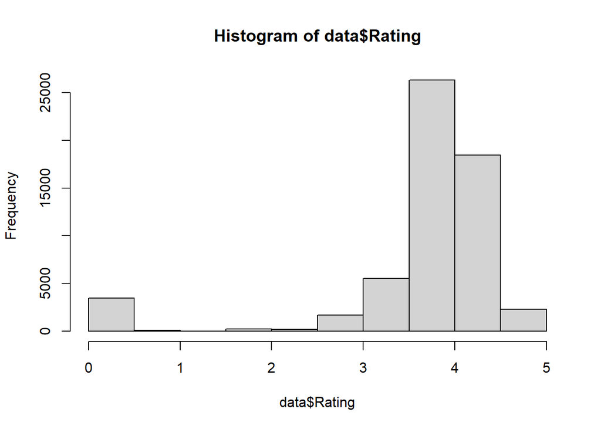

```r
hist(data$Rating)
```

La figura anterior representa un histograma que muestra la distribución de los *ratings* donde es posible observar que la mayor parte oscila entre los valores 3.5 y 4.5.

A continuación se listan un conjunto de requerimientos informacionales y las sentencias que dan respuesta utilizando la biblioteca **dplyr**. Nótese que en todos los casos se ha truncado el dataframe respuesta para una mejor visualización.

1. Determinar los libros que tienen la máxima evaluación

```r
library(dplyr)
data %>%
  select(Name, Rating) %>%
  filter(Rating == max(Rating)) %>%
  slice_head(n=3)
```

```
##                                                            Name Rating
## 1                               A Colorful Symphony: Full Score      5
## 2                                 Bullets, Badges, and Bullshit      5
## 3 New York Trilogy: New York Underground, Trapped, Love and Sex      5
```

2. Determinar los libros que han logrado recoger el mayor número de reviews y Ratings

```r
data %>%
  select(Name, RatingDistTotal, CountsOfReview) %>%
  arrange(desc(CountsOfReview), desc(RatingDistTotal)) %>%
  slice_head(n=3)
```

[output not shown]

3. Determinar los libros que mayor cantidad de ratings con valor 5 tienen

```r
data %>%
  select(Name, Authors, RatingDist5) %>%
  arrange(desc(RatingDist5)) %>%
  slice_head(n=3)
```

[output not shown]

4. Determinar la cantidad de libros publicados por editorial

```r
data %>%
  group_by(Publisher) %>%
  summarize(books_count = n()) %>%
  arrange(desc(books_count)) %>%
  slice_head(n=3)
```

```
## # A tibble: 3 x 2
##   Publisher                    books_count
##   <chr>                              <int>
## 1 Vintage                              829
## 2 Oxford University Press, USA         723
## 3 Penguin Books                        692
```

5. Listar la media de ratings obtenida por autor para aquellos autores que han publicado al menos 50 títulos

```r
data %>%
  group_by(Authors) %>%
  summarise(mean = mean(Rating), count = n()) %>%
  filter(count >= 50) %>%
  arrange(desc(mean)) %>%
  slice_head(n=3)
```

```
## # A tibble: 3 x 3
##   Authors           mean count
##   <chr>            <dbl> <int>
## 1 J.K. Rowling      4.52    60
## 2 J.R.R. Tolkien    4.19    91
## 3 Rumiko Takahashi  4.17    83
```

```r
data %>%
  group_by(Authors) %>%
  summarise(mean = mean(pagesNumber), count = n()) %>%
  filter(count >= 10) %>%
  arrange(desc(mean)) %>%
  slice_head(n=3)
```

```
## # A tibble: 3 x 3
##   Authors               mean count
##   <chr>                <dbl> <int>
## 1 Winston S. Churchill 1033     10
## 2 Robert Jordan        1021.    13
## 3 Diana Gabaldon        803.    11
```

7. La cantidad de libros escritos por idioma

```r
data %>%
  group_by(Language) %>%
  summarise(count = n()) %>%
  arrange(desc(count)) %>%
  slice_head(n=3)
```

```
## # A tibble: 3 x 2
##   Language count
##   <chr>    <int>
## 1 <NA>     37998
## 2 eng      15988
## 3 en-US     2456
```

8. El libro que ha recibido el mejor rating en cada año

```r
data %>%
  select(Name, PublishYear, Rating) %>%
  group_by(PublishYear) %>%
  filter(Rating == max(Rating)) %>%
  arrange(PublishYear) %>%
  slice_head(n=3)
```

```
## # A tibble: 182 x 3
## # Groups:   PublishYear [105]
##    Name                                                       PublishYear Rating
##    <chr>                                                            <int>  <dbl>
##  1 The Secret of the Old Mill (The Hardy Boys, #3)                    162   3.86
##  2 Lives Of James Madison & James Monroe (The Works Of John ~        1850   4.5
##  3 Consider the Lilies                                               1900   3.88
##  4 Greek Bucolic Poets: Theocritus. Bion. Moschus                    1912   4.02
##  5 On Duties (De Officiis)                                           1913   3.96
##  6 Agricola / Germania / Dialogue on Oratory                         1914   3.96
##  7 History of the Peloponnesian War: Bk. 1-2                         1919   4.32
##  8 History of the Peloponnesian War: Bk. 5-6                         1921   4.36
##  9 Comoediae 1: Acharenses/Equites/Nubes/Vespae/Pax/Aves             1922   5
## 10 History of the Peloponnesian War, Bk. 7-8                         1923   4.31
## # ... with 172 more rows
```